# Week 5 Tutorials: Visualising Random Processes

161.307 Reproducible Visualisation for Statistics

Author

School of Mathematical and Computational Sciences, Massey University

Published

12 Aug 2026

## Overview

Three sessions this week:

1. **Tutorial 1** - Generating and plotting single realisations
2. **Tutorial 2** - Many realisations: spaghetti and small multiples
3. **Tutorial 3** - Summarising ensembles with ribbons, and a short written comparison exercise

```r
library(ggplot2)
library(dplyr)
```

## Tutorial 1: Generating and plotting single realisations

### 1.1 A random walk

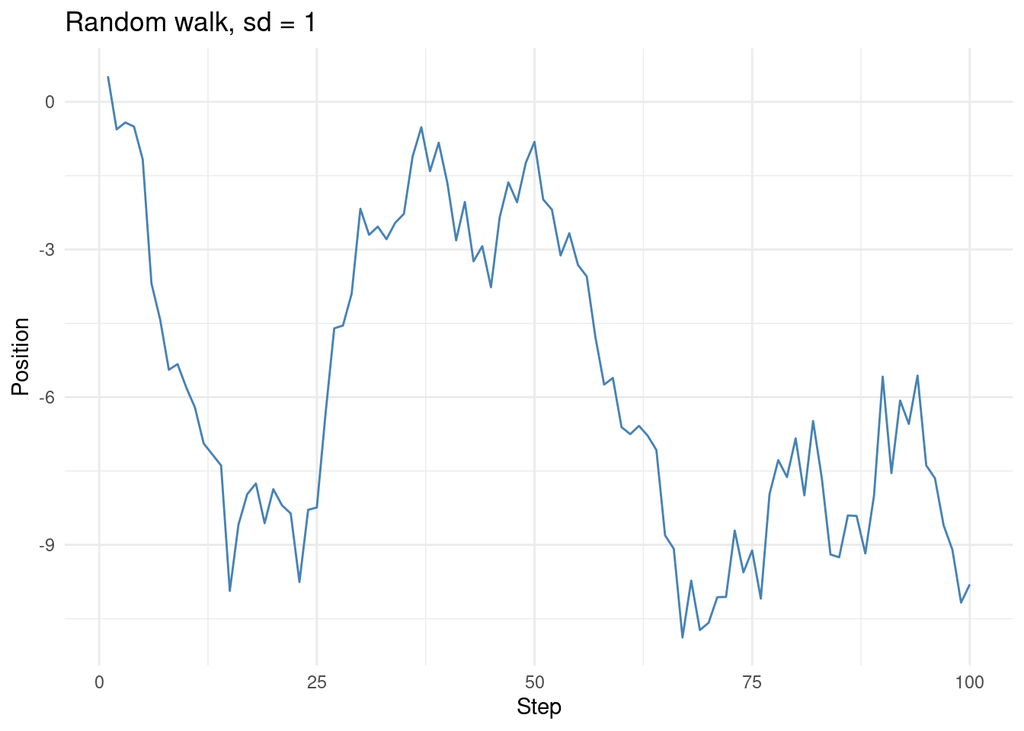

```r
set.seed(2026)
n <- 100

walk_df <- data.frame(
  time = 1:n,
  position = cumsum(rnorm(n, mean = 0, sd = 1))
)

ggplot(walk_df, aes(time, position)) +
  geom_line(colour = "steelblue") +
  labs(title = "Random walk, sd = 1",
       x = "Step", y = "Position") +
  theme_minimal()
```

**Exercise 1.1** - Re-run the simulation with `sd = 0.5` and `sd = 2` (use a new seed for each so they’re distinguishable, but record the seeds). Plot all three on the same axes using `colour` to distinguish them. What do you notice about the *range* of the y-axis as `sd` changes?

### 1.2 Faceting by parameter

**Exercise 1.2** - Instead of overlaying, generate one realisation each for `sd ∈ {0.5, 1, 2}` and `drift ∈ {0, 0.1}` (i.e. add a constant to each step: `rnorm(n, mean = drift, sd = sd)`), giving 6 combinations. Store them in one long data frame with columns `time`, `position`, `sd`, `drift`, then use `facet_grid(sd ~ drift)` to display all 6 panels. Make sure axis labels and a shared title clearly communicate what varies between panels.

> **Reproducibility checkpoint**: make sure your seed is set *once*, before the loop/`replicate()` that generates all 6 series .Do not reset inside the loop and document why that matters.

## Tutorial 2: Many realisations - spaghetti and small multiples

### 2.1 Generating an ensemble

```r
set.seed(2026)
n_steps <- 100
n_sims  <- 50

sims <- lapply(1:n_sims, function(i) {
  data.frame(sim = i, time = 1:n_steps,
             position = cumsum(rnorm(n_steps)))
})
sims <- bind_rows(sims)
```

### 2.2 Spaghetti plot

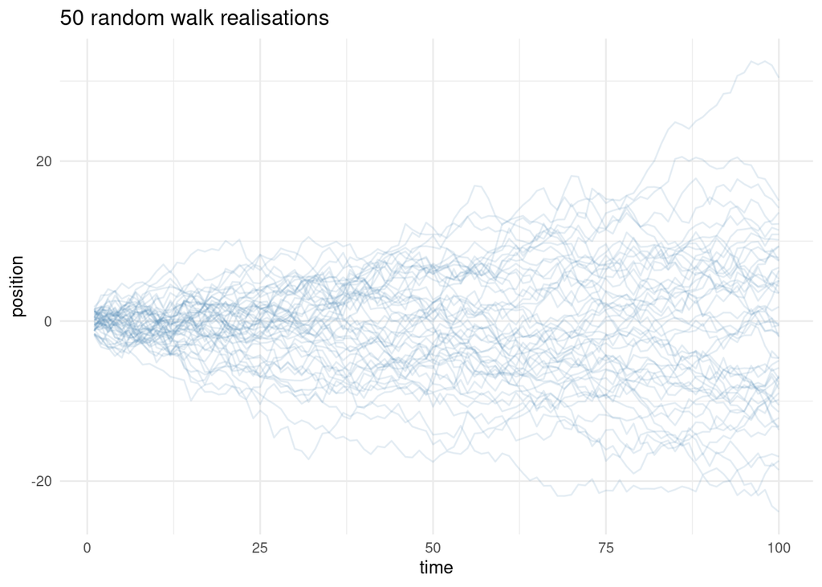

```r
ggplot(sims, aes(time, position, group = sim)) +
  geom_line(alpha = 0.15, colour = "steelblue") +
  labs(title = "50 random walk realisations") +
  theme_minimal()
```

**Exercise 2.1** - Try `alpha = 1`, `alpha = 0.3`, `alpha = 0.05` with `n_sims = 50`, then repeat with `n_sims = 500`. Produce a small grid of these (e.g. with `patchwork` or `facet_wrap` over a manually-created “version” column) and write 2-3 sentences: at what combination of `n` and `alpha` does the plot stop being useful, and why?

### 2.3 Small multiples

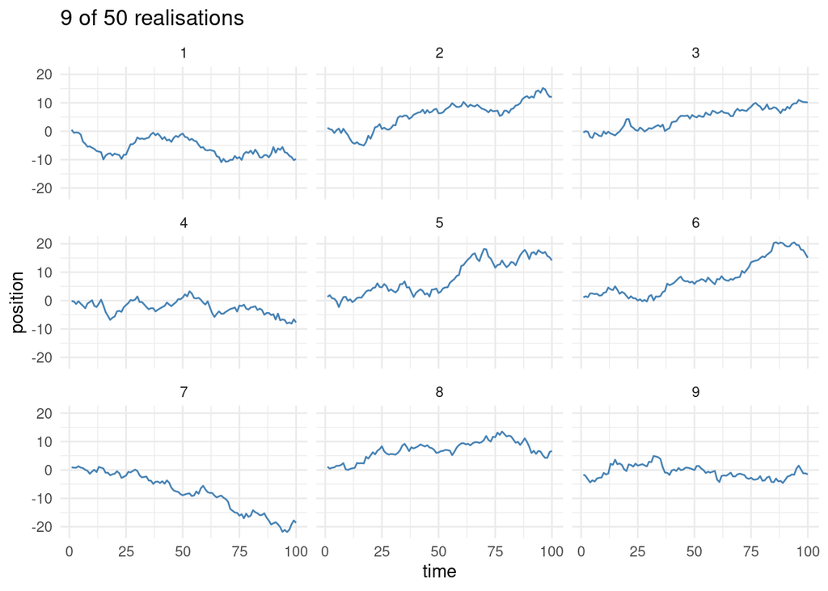

```r
sims |>
  filter(sim <= 9) |>
  ggplot(aes(time, position)) +
  geom_line(colour = "steelblue") +
  facet_wrap(~ sim, nrow = 3) +
  labs(title = "9 of 50 realisations") +
  theme_minimal()
```

**Exercise 2.2** - Small multiples don’t scale to 50 panels on one slide/page. Find (empirically, by trying it) roughly how many panels you can fit in a `facet_wrap` before the plot becomes unreadable at a typical screen size. Report the number and the `fig-width`/`fig-height` you used.

### 2.4 Discussion (bring to class)

- For the random walk ensemble, which representation among spaghetti or small multiples better conveys:
  1. the *typical* trajectory shape,
  2. the *spread* of outcomes at the final time point,
  3. whether any individual trajectory is unusual?
- Is there a process (think of examples from your own field of interest) where small multiples would clearly be preferable, regardless of `n`?

## Tutorial 3: Summarising ensembles

### 3.1 From realisations to summaries

```r
set.seed(2026)
n_steps <- 100
n_sims  <- 500

sims_big <- lapply(1:n_sims, function(i) {
  data.frame(sim = i, time = 1:n_steps,
             position = cumsum(rnorm(n_steps)))
})
sims_big <- bind_rows(sims_big)

summary_df <- sims_big |>
  group_by(time) |>
  summarise(
    median  = median(position),
    lower50 = quantile(position, 0.25),
    upper50 = quantile(position, 0.75),
    lower90 = quantile(position, 0.05),
    upper90 = quantile(position, 0.95),
    .groups = "drop"
  )
```

**Exercise 3.1** - Before plotting, predict: will the 90% band get wider or narrower over time for a random walk with no drift? Why? Then check your prediction against the plot in Section 3.2.

### 3.2 Ribbon plots and comparison

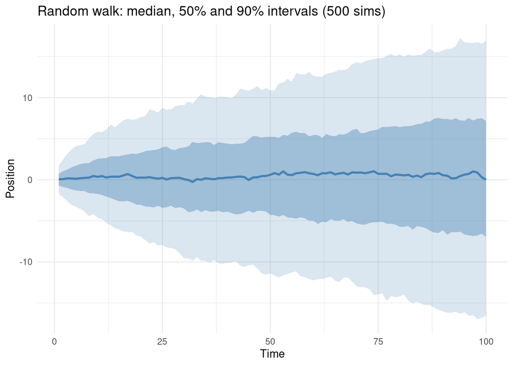

```r
ggplot(summary_df, aes(time)) +
  geom_ribbon(aes(ymin = lower90, ymax = upper90),
              alpha = 0.2, fill = "steelblue") +
  geom_ribbon(aes(ymin = lower50, ymax = upper50),
              alpha = 0.4, fill = "steelblue") +
  geom_line(aes(y = median), colour = "steelblue", linewidth = 1) +
  labs(title = "Random walk: median, 50% and 90% intervals (500 sims)",
       x = "Time", y = "Position") +
  theme_minimal()
```

**Exercise 3.2** - Add a few individual trajectories (e.g. 10 randomly sampled `sim` values, using `geom_line` with low alpha) *on top of* the ribbon plot. Does this help or clutter? Try it both ways and pick the version you think communicates better. Justify your choice in 1–3 (short if 3) sentences.

> **Looking ahead**: keep your ensemble data frame (or the code that generates it). Week 6’s tutorials will revisit the ribbon idea, but applied to *model-based* intervals (confidence/prediction intervals, bootstrap distributions) rather than simulation ensembles. The visual grammar is the same; the source of the uncertainty differs.